# Notebook 4

### Objectifs

#### * Calculer les taux de suicide dans différents pays du Monde

#### * Sélectionner les cas extrêmes et les pays intéressants

#### * Comparer l'évolution des taux de suicide dans ces différents pays

#### * Tenter de corréler les évolutions avec différents facteurs

Penser à utiliser le jeu de données sans valeurs aberrantes, data avec PIB, IDH, etc

```python
import pandas as pd
import pylab as pl
import numpy as np
import matplotlib
import matplotlib.pyplot as plt
```

```python
dfBS = pd.read_csv('./Data/Both_Sexes_10y.csv', sep=',')
dfBS = dfBS.drop('Unnamed: 0', axis = 1)
dfBS
```

|  | Country | 10-19 years | 20-29 years | 30-39 years | 40-49 years | 50-59 years | 60-69 years | 70-79 years | 80+ years | Nb inhabitant |
| --- | --- | --- | --- | --- | --- | --- | --- | --- | --- | --- |
| 0 | Afghanistan | 3.1 | 10.2 | 9.2 | 6.6 | 5.6 | 5.5 | 11.0 | 42.0 | 35383128.0 |
| 1 | Albania | 5.0 | 6.5 | 6.1 | 9.1 | 7.8 | 6.0 | 8.3 | 16.3 | 2876101.0 |
| 2 | Algeria | 1.3 | 4.2 | 5.3 | 4.7 | 4.1 | 4.2 | 5.6 | 9.4 | 40551404.0 |
| 3 | Angola | 2.6 | 6.6 | 5.4 | 7.0 | 14.8 | 23.8 | 42.1 | 63.5 | 28842484.0 |
| 4 | Argentina | 8.6 | 15.3 | 10.8 | 9.8 | 9.5 | 10.0 | 11.6 | 15.8 | 43590368.0 |
| ... | ... | ... | ... | ... | ... | ... | ... | ... | ... | ... |
| 139 | United States of America | 6.3 | 18.0 | 19.2 | 19.3 | 21.7 | 17.9 | 18.4 | 25.1 | 323071342.0 |
| 140 | Uruguay | 8.1 | 23.0 | 20.6 | 22.0 | 22.1 | 23.6 | 32.7 | 38.9 | 3424132.0 |
| 141 | Uzbekistan | 9.0 | 10.6 | 9.3 | 9.7 | 7.5 | 7.1 | 6.6 | 4.8 | 31847900.0 |
| 142 | Zambia | 2.8 | 8.3 | 8.9 | 11.8 | 18.7 | 25.8 | 48.9 | 79.7 | 16363507.0 |
| 143 | Zimbabwe | 4.6 | 11.3 | 13.7 | 19.2 | 29.4 | 41.3 | 81.5 | 205.7 | 14030390.0 |

144 rows × 10 columns

```python
dfGlobal = pd.read_csv('./Data/dataGlobal.csv', sep=',')
dfGlobal.drop('Unnamed: 0', axis = 1, inplace =True)

dfGlobal = dfGlobal.sort_values(by = 'Age standardized suicide rate')
dfGlobal.head()
```

|  | Country | HDI in 2016 | HDI Rank (2017) | Age standardized suicide rate | PIB $ | Nb inhabitants | PIB/hab | 10-14 years | 15-19 years | 20-24 years | 25-29 years |
| --- | --- | --- | --- | --- | --- | --- | --- | --- | --- | --- | --- |
| 12 | Barbados | 0.799 | 58 | 0.4 | 4.529050e+09 | 285796.0 | 15847.142717 | 0.0 | 0.0 | 0.0 | 0.0 |
| 4 | Antigua and Barbuda | 0.778 | 70 | 0.5 | 1.464630e+09 | 94527.0 | 15494.305472 | 0.0 | 0.0 | 0.0 | 0.0 |
| 56 | Grenada | 0.770 | 75 | 1.7 | 1.061631e+09 | 110261.0 | 9628.347487 | 0.0 | 0.0 | 0.0 | 0.0 |
| 71 | Jamaica | 0.732 | 97 | 2.0 | 1.407214e+10 | 2906238.0 | 4842.045011 | 0.4 | 1.9 | 2.8 | 2.9 |
| 77 | Kuwait | 0.804 | 56 | 2.2 | 1.094201e+11 | 3956873.0 | 27653.164401 | 0.2 | 1.5 | 3.4 | 4.9 |

```python
dfGlobal.describe()
```

|  | HDI in 2016 | HDI Rank (2017) | Age standardized suicide rate | PIB $ | Nb inhabitants | PIB/hab | 10-14 years | 15-19 years | 20-24 years | 25-29 years |
| --- | --- | --- | --- | --- | --- | --- | --- | --- | --- | --- |
| count | 156.000000 | 156.000000 | 156.000000 | 1.560000e+02 | 1.560000e+02 | 156.000000 | 156.000000 | 156.000000 | 156.000000 | 156.000000 |
| mean | 0.707936 | 94.025641 | 9.771154 | 4.414584e+11 | 4.276798e+07 | 13048.215835 | 1.256410 | 7.015385 | 10.476923 | 10.689744 |
| std | 0.154896 | 55.222944 | 5.640613 | 1.818580e+12 | 1.572138e+08 | 18214.094332 | 1.158151 | 5.281192 | 7.221508 | 7.298645 |
| min | 0.351000 | 1.000000 | 0.400000 | 1.783289e+08 | 9.452700e+04 | 282.149682 | 0.000000 | 0.000000 | 0.000000 | 0.000000 |
| 25% | 0.585750 | 46.750000 | 5.700000 | 1.005786e+10 | 2.580291e+06 | 1923.261100 | 0.400000 | 3.200000 | 5.050000 | 5.400000 |
| 50% | 0.740500 | 92.000000 | 8.900000 | 3.855999e+10 | 9.315888e+06 | 5147.627196 | 0.900000 | 5.350000 | 8.100000 | 8.600000 |
| 75% | 0.823500 | 143.250000 | 12.900000 | 2.100605e+11 | 2.799294e+07 | 15006.359542 | 1.800000 | 9.000000 | 13.625000 | 14.050000 |
| max | 0.951000 | 189.000000 | 30.200000 | 1.870719e+13 | 1.378665e+09 | 101305.527723 | 7.100000 | 28.900000 | 42.000000 | 38.400000 |

```python
dfGlobal[dfGlobal['Country'] == 'Guyana']
#Etude d'un pays avec un des plus forts taux de suicide du monde
```

|  | Country | HDI in 2016 | HDI Rank (2017) | Age standardized suicide rate | PIB $ | Nb inhabitants | PIB/hab | 10-14 years | 15-19 years | 20-24 years | 25-29 years |
| --- | --- | --- | --- | --- | --- | --- | --- | --- | --- | --- | --- |
| 60 | Guyana | 0.652 | 125 | 30.2 | 3.504024e+09 | 771366.0 | 4542.622067 | 7.1 | 28.9 | 42.0 | 31.8 |

```python
dfGlobal[dfGlobal['Country'] == 'Greece']
#Etude d'un pays avec un des plus faibles taux de suicide du monde
```

|  | Country | HDI in 2016 | HDI Rank (2017) | Age standardized suicide rate | PIB $ | Nb inhabitants | PIB/hab | 10-14 years | 15-19 years | 20-24 years | 25-29 years |
| --- | --- | --- | --- | --- | --- | --- | --- | --- | --- | --- | --- |
| 55 | Greece | 0.868 | 31 | 3.8 | 1.952224e+11 | 10775971.0 | 18116.459622 | 0.1 | 1.3 | 3.8 | 4.1 |

# Etude de la France

Population totale par sexe et âge au 1er janvier 2019, France métropolitaine Mis à jour : janvier 2019 Champ : France métropolitaine Source : Insee, estimations de population (résultats provisoires à fin 2018)

Tuax de suicide associé par catégorie d'âge

```python
dfFrance = pd.read_csv('./Data/age_France.csv', sep=',')
dfFrance
```

|  | Critère | 10-19 years | 20-29 years | 30-39 years | 40-49 years | 50-59 years | 60-69 years | 70-79 years | 80+ years |
| --- | --- | --- | --- | --- | --- | --- | --- | --- | --- |
| 0 | Nb hab | 7958885.0 | 7306158.0 | 8035336.0 | 8388238.0 | 8532078.0 | 7803284.0 | 5331800.0 | 3969849.0 |
| 1 | Taux suicide | 2.2 | 8.0 | 13.4 | 21.8 | 23.2 | 20.3 | 27.2 | 73.4 |

```python
dfFranceT = dfFrance.transpose()
dfFranceT = dfFranceT.drop('Critère', axis = 0)
dfFranceT
```

|  | 0 | 1 |
| --- | --- | --- |
| 10-19 years | 7.95888e+06 | 2.2 |
| 20-29 years | 7.30616e+06 | 8 |
| 30-39 years | 8.03534e+06 | 13.4 |
| 40-49 years | 8.38824e+06 | 21.8 |
| 50-59 years | 8.53208e+06 | 23.2 |
| 60-69 years | 7.80328e+06 | 20.3 |
| 70-79 years | 5.3318e+06 | 27.2 |
| 80+ years | 3.96985e+06 | 73.4 |

```python
dfFranceT.iloc[:,1] = pd.to_numeric(dfFranceT.iloc[:,1])
dfFranceT['Taux standardisé par âge pour 100000 habitants'] = dfFranceT[1]*100000 / dfFranceT[0]
#pour 100 000 habitants

dfFranceT['Age'] = [15,25,35,45,55,65,75,85]

dfFranceT.rename(columns={0: 'Nb inhabitant', 1:'Taux de suicide'}, inplace=True)
```

```python
dfFranceT
```

|  | Nb inhabitant | Taux de suicide | Taux standardisé par âge pour 100000 habitants | Age |
| --- | --- | --- | --- | --- |
| 10-19 years | 7.95888e+06 | 2.2 | 0.0276421 | 15 |
| 20-29 years | 7.30616e+06 | 8.0 | 0.109497 | 25 |
| 30-39 years | 8.03534e+06 | 13.4 | 0.166763 | 35 |
| 40-49 years | 8.38824e+06 | 21.8 | 0.259888 | 45 |
| 50-59 years | 8.53208e+06 | 23.2 | 0.271915 | 55 |
| 60-69 years | 7.80328e+06 | 20.3 | 0.260147 | 65 |
| 70-79 years | 5.3318e+06 | 27.2 | 0.510147 | 75 |
| 80+ years | 3.96985e+06 | 73.4 | 1.84894 | 85 |

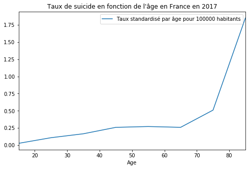

```python
#création d'une fenêtre Matplotlib
fig, ax = plt.subplots(1, figsize=(8,5));
dfFranceT.plot(x = 'Age',y ='Taux standardisé par âge pour 100000 habitants', ax = ax);
ax.set_title("Taux de suicide en fonction de l'âge en France en 2017");

plt.savefig('NB4_0.png');
```

```python
dfFranceT.to_csv('./Data/dataFrance.csv')
```

On constate que le taux de suicide explose pour les plus de 80ans.

On peut mettre en cause la mauvaise prise en charge des personnes agếes, leurs conditions de vie, la solitude et le sentiment d'exclusion de la société

Dans d'autres cultures, principalement au Maghreb (Afrique du Nord), la personne âgée est respectée, elle fait figure de sagesse et est le témoin d'une génération entière. Accueillies dans leur famille lorsqu'elle ne sont plus autonomes, les seniors conservent une place à part entière dans la société, quelque soit leur âge

```python
dfBS = dfBS.sort_values(by = "80+ years")
dfBS.head(10)
```

|  | Country | 10-19 years | 20-29 years | 30-39 years | 40-49 years | 50-59 years | 60-69 years | 70-79 years | 80+ years | Nb inhabitant |
| --- | --- | --- | --- | --- | --- | --- | --- | --- | --- | --- |
| 70 | Kuwait | 0.8 | 4.3 | 3.4 | 2.1 | 2.3 | 2.6 | 4.9 | 0.0 | 3956873.0 |
| 83 | Mauritius | 3.7 | 12.9 | 11.8 | 11.0 | 7.4 | 6.4 | 5.5 | 4.0 | 1263473.0 |
| 141 | Uzbekistan | 9.0 | 10.6 | 9.3 | 9.7 | 7.5 | 7.1 | 6.6 | 4.8 | 31847900.0 |
| 65 | Jamaica | 1.2 | 2.8 | 2.5 | 2.7 | 2.9 | 2.8 | 3.7 | 5.3 | 2906238.0 |
| 138 | United Arab Emirates | 1.8 | 4.0 | 2.8 | 2.8 | 3.2 | 4.4 | 5.6 | 6.7 | 9360980.0 |
| 34 | Cyprus | 1.6 | 6.2 | 6.1 | 6.2 | 6.3 | 8.9 | 7.4 | 6.8 | 1170187.0 |
| 51 | Greece | 0.7 | 4.0 | 4.3 | 6.4 | 7.5 | 7.1 | 6.4 | 7.2 | 10775971.0 |
| 52 | Guatemala | 3.1 | 4.3 | 3.2 | 3.5 | 3.1 | 4.1 | 2.8 | 7.4 | 16583060.0 |
| 99 | Pakistan | 3.1 | 5.5 | 3.8 | 2.9 | 2.7 | 2.9 | 4.0 | 7.5 | 203627284.0 |
| 8 | Azerbaijan | 1.4 | 2.2 | 3.2 | 3.5 | 4.1 | 4.5 | 6.6 | 7.7 | 9757812.0 |

Nous comparons avec une carte sur le Notebook 4 bis afin de confirmer ou infirmer cette hypothèse. Pour autant, ces données ne sont pas réellement représentatives car elles sont pondérées par le nombre total d'habitant et non pas par le nombre de personnes de + de 80 ans

# Etude de trois "gros" pays

## Chine, Etats-Unis et Inde

```python
dfBS = dfBS.sort_values(by = "Nb inhabitant", ascending= False )
dfBS.head(3)
```

|  | Country | 10-19 years | 20-29 years | 30-39 years | 40-49 years | 50-59 years | 60-69 years | 70-79 years | 80+ years | Nb inhabitant |
| --- | --- | --- | --- | --- | --- | --- | --- | --- | --- | --- |
| 28 | China | 1.9 | 5.0 | 6.0 | 6.3 | 10.5 | 23.4 | 44.0 | 61.3 | 1.378665e+09 |
| 59 | India | 11.2 | 30.3 | 22.9 | 17.7 | 16.8 | 17.5 | 21.9 | 24.5 | 1.324510e+09 |
| 139 | United States of America | 6.3 | 18.0 | 19.2 | 19.3 | 21.7 | 17.9 | 18.4 | 25.1 | 3.230713e+08 |

Pourquoi étudier ces 3 pays ? Ces pays sont les plus peuplés du monde, nous ésperons donc que la forte population nous permette d'avoir des valeurs plus fiables liées à une taille d'échantillon plus élevée.

```python
dfGlobal = dfGlobal.sort_values(by = "Nb inhabitants", ascending= False )
dfGlobal.head(3)
```

|  | Country | HDI in 2016 | HDI Rank (2017) | Age standardized suicide rate | PIB $ | Nb inhabitants | PIB/hab | 10-14 years | 15-19 years | 20-24 years | 25-29 years |
| --- | --- | --- | --- | --- | --- | --- | --- | --- | --- | --- | --- |
| 32 | China | 0.748 | 86 | 8.0 | 1.113795e+13 | 1.378665e+09 | 8078.790474 | 0.9 | 2.8 | 4.3 | 5.6 |
| 65 | India | 0.636 | 130 | 16.5 | 2.290432e+12 | 1.324510e+09 | 1729.268021 | 2.6 | 20.0 | 30.7 | 30.0 |
| 150 | United States | 0.922 | 13 | 13.7 | 1.870719e+13 | 3.230713e+08 | 57904.201961 | 2.1 | 10.4 | 17.2 | 18.7 |

```python
dfMean = dfBS.describe()
dfMean = dfMean.drop('Nb inhabitant', axis = 1).transpose()
dfMean['Age'] = [15,25,35,45,55,65,75,85]
dfMean
```

|  | count | mean | std | min | 25% | 50% | 75% | max | Age |
| --- | --- | --- | --- | --- | --- | --- | --- | --- | --- |
| 10-19 years | 144.0 | 4.134028 | 2.852680 | 0.7 | 2.175 | 3.40 | 5.300 | 18.3 | 15 |
| 20-29 years | 144.0 | 10.865278 | 6.958753 | 2.2 | 5.650 | 8.90 | 14.075 | 38.0 | 25 |
| 30-39 years | 144.0 | 11.488889 | 7.999983 | 2.5 | 6.075 | 9.15 | 14.225 | 49.7 | 35 |
| 40-49 years | 144.0 | 12.811806 | 8.652357 | 2.1 | 6.675 | 10.50 | 16.700 | 54.8 | 45 |
| 50-59 years | 144.0 | 15.409722 | 9.859093 | 2.3 | 7.575 | 12.75 | 21.700 | 48.5 | 55 |
| 60-69 years | 144.0 | 17.658333 | 11.522435 | 2.6 | 8.275 | 16.35 | 23.725 | 55.4 | 65 |
| 70-79 years | 144.0 | 26.306250 | 21.108366 | 2.8 | 9.800 | 19.15 | 36.175 | 99.1 | 75 |
| 80+ years | 144.0 | 41.976389 | 35.705777 | 0.0 | 15.775 | 32.60 | 54.100 | 205.7 | 85 |

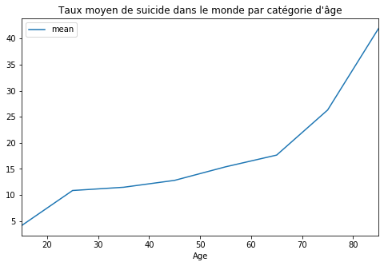

```python
fig, ax = plt.subplots(1, figsize=(8,5));
dfMean.plot(x = 'Age',y ='mean', ax = ax);
ax.set_title("Taux moyen de suicide dans le monde par catégorie d'âge");

plt.savefig('NB4_1.png');

#résultat non exploitable car pas de pondération par catégorie d'âge
```

Par une étude du PIB, de l'IDH et d'autres critères, nous essayerons d'interpréter ces résultats.

```python
df = pd.read_csv('./Data/AS_2000-2016.csv', sep=',')
df
```

|  | Country | Sex | 2016 | 2015 | 2010 | 2000 |
| --- | --- | --- | --- | --- | --- | --- |
| 0 | Afghanistan | Both sexes | 6.4 | 6.6 | 7.4 | 8.1 |
| 1 | Afghanistan | Male | 10.6 | 10.9 | 12.5 | 14.3 |
| 2 | Afghanistan | Female | 2.1 | 2.1 | 2.1 | 1.7 |
| 3 | Albania | Both sexes | 5.6 | 5.3 | 7.7 | 5.8 |
| 4 | Albania | Male | 7.0 | 6.7 | 9.5 | 8.2 |
| ... | ... | ... | ... | ... | ... | ... |
| 544 | Zambia | Male | 17.5 | 17.4 | 17.9 | 21.9 |
| 545 | Zambia | Female | 6.2 | 6.1 | 6.2 | 7.5 |
| 546 | Zimbabwe | Both sexes | 19.1 | 18.9 | 20.6 | 21.7 |
| 547 | Zimbabwe | Male | 29.1 | 28.7 | 32.3 | 35.5 |
| 548 | Zimbabwe | Female | 11.1 | 11.1 | 11.1 | 9.8 |

549 rows × 6 columns

```python
#passer les valeurs de cdc à numérique
for i in range(2,6) :
    df.iloc[:,i] = pd.to_numeric(df.iloc[:,i])
df.head(20)

#création de 3 df : Both Sexes, Male et Female
dfAS = df[df['Sex'] == 'Both sexes'].drop('Sex', axis = 1)
dfAS.index = range(0, dfAS.shape[0])
dfMale = df[df['Sex'] == 'Male'].drop('Sex', axis = 1)
dfMale.index = range(0, dfMale.shape[0])
dfFemale = df[df['Sex'] == 'Female'].drop('Sex', axis = 1)
dfFemale.index = range(0, dfFemale.shape[0])

dfAS.head(5)
```

|  | Country | 2016 | 2015 | 2010 | 2000 |
| --- | --- | --- | --- | --- | --- |
| 0 | Afghanistan | 6.4 | 6.6 | 7.4 | 8.1 |
| 1 | Albania | 5.6 | 5.3 | 7.7 | 5.8 |
| 2 | Algeria | 3.3 | 3.4 | 3.5 | 4.7 |
| 3 | Angola | 8.9 | 9.3 | 10.4 | 13.9 |
| 4 | Antigua and Barbuda | 0.5 | 0.8 | 0.2 | 2.1 |

```python
dfIh = pd.read_csv('./Data/inhabitants.csv', sep=',')
dfIh.iloc[:,1] = pd.to_numeric(dfIh.iloc[:,1])
dfIh.rename(columns={'2016': 'Nb inhabitant'}, inplace=True)

dfAS = dfAS.merge(dfIh, left_on = 'Country', right_on ='Country')
dfAS = dfAS.sort_values(by = 'Nb inhabitant', ascending = False)
dfAS
```

|  | Country | 2016 | 2015 | 2010 | 2000 | Nb inhabitant |
| --- | --- | --- | --- | --- | --- | --- |
| 32 | China | 8.0 | 8.1 | 10.0 | 14.1 | 1.378665e+09 |
| 66 | India | 16.5 | 16.7 | 17.1 | 18.7 | 1.324510e+09 |
| 153 | United States of America | 13.7 | 13.3 | 11.8 | 10.1 | 3.230713e+08 |
| 67 | Indonesia | 3.7 | 3.7 | 4.0 | 4.3 | 2.615542e+08 |
| 20 | Brazil | 6.1 | 6.2 | 5.7 | 5.3 | 2.061631e+08 |
| ... | ... | ... | ... | ... | ... | ... |
| 57 | Grenada | 1.7 | 1.1 | 0.9 | 2.7 | 1.102610e+05 |
| 145 | Tonga | 4.0 | 4.0 | 4.3 | 4.5 | 1.011330e+05 |
| 126 | Seychelles | 8.3 | 8.5 | 9.0 | 9.4 | 9.467700e+04 |
| 4 | Antigua and Barbuda | 0.5 | 0.8 | 0.2 | 2.1 | 9.452700e+04 |
| 45 | Eritrea | 13.8 | 14.1 | 15.0 | 18.9 | NaN |

159 rows × 6 columns

```python
#On s'intéresse au tableau des taux de suicide "Age Standardized" Réduit à nos trois pays
#Estimation des taux de suicide, age-standardized Estimations par pays et par sexe, pour 100 000 hab

dfASR = dfAS.head(4)
dfASR = dfASR.drop('Nb inhabitant', axis = 1)
dfASR = dfASR.transpose()
dfASR = dfASR.drop('Country', axis = 0)
dfASR = dfASR.rename(columns={32: 'China', 66:'India', 153: 'United States of America', 67: 'Indonesia'})
dfASR['Year']=[2016,2015,2010,2000]
dfASR
```

|  | China | India | United States of America | Indonesia | Year |
| --- | --- | --- | --- | --- | --- |
| 2016 | 8 | 16.5 | 13.7 | 3.7 | 2016 |
| 2015 | 8.1 | 16.7 | 13.3 | 3.7 | 2015 |
| 2010 | 10 | 17.1 | 11.8 | 4 | 2010 |
| 2000 | 14.1 | 18.7 | 10.1 | 4.3 | 2000 |

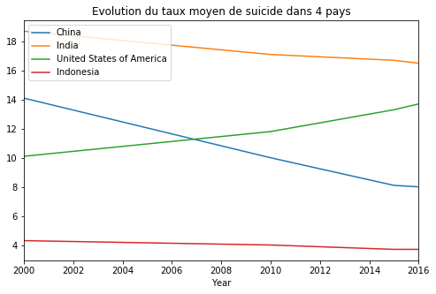

```python
fig, ax = plt.subplots(1, figsize=(8,5));
dfASR.plot(x = 'Year', ax = ax);
ax.set_title("Evolution du taux moyen de suicide dans 4 pays");

plt.savefig('NB4_2.png');
```

On remarque que, si l'Inde est le pays avec le plus fort taux de suicide, il est sur la voie d'une amélioration avec un baisse constante de ce taux depuis 2000. A l'inverse, on constate que ce taux est en forte hausse aux Etats-Unis. Contrairement à ce que l'on pourrait croire, un pays dévellopé n'implique pas systématiquement un taux de suicide faible.

## Etude de l'évolution des taux de suicide

```python
dfAS
```

|  | Country | 2016 | 2015 | 2010 | 2000 | Nb inhabitant |
| --- | --- | --- | --- | --- | --- | --- |
| 32 | China | 8.0 | 8.1 | 10.0 | 14.1 | 1.378665e+09 |
| 66 | India | 16.5 | 16.7 | 17.1 | 18.7 | 1.324510e+09 |
| 153 | United States of America | 13.7 | 13.3 | 11.8 | 10.1 | 3.230713e+08 |
| 67 | Indonesia | 3.7 | 3.7 | 4.0 | 4.3 | 2.615542e+08 |
| 20 | Brazil | 6.1 | 6.2 | 5.7 | 5.3 | 2.061631e+08 |
| ... | ... | ... | ... | ... | ... | ... |
| 57 | Grenada | 1.7 | 1.1 | 0.9 | 2.7 | 1.102610e+05 |
| 145 | Tonga | 4.0 | 4.0 | 4.3 | 4.5 | 1.011330e+05 |
| 126 | Seychelles | 8.3 | 8.5 | 9.0 | 9.4 | 9.467700e+04 |
| 4 | Antigua and Barbuda | 0.5 | 0.8 | 0.2 | 2.1 | 9.452700e+04 |
| 45 | Eritrea | 13.8 | 14.1 | 15.0 | 18.9 | NaN |

159 rows × 6 columns

```python
dfAS['Evolution 2000-2016'] = dfAS['2016'] - dfAS['2000']
dfAS = dfAS.sort_values(by = 'Evolution 2000-2016')
dfA1 = dfAS.head(3)
dfA1

#sélection des trois pays avec la plus forte baisse du taux de suicide
```

|  | Country | 2016 | 2015 | 2010 | 2000 | Nb inhabitant | Evolution 2000-2016 |
| --- | --- | --- | --- | --- | --- | --- | --- |
| 119 | Russian Federation | 26.5 | 27.5 | 34.5 | 47.5 | 144342396.0 | -21.0 |
| 84 | Lithuania | 25.7 | 28.8 | 31.3 | 46.3 | 2868231.0 | -20.6 |
| 13 | Belarus | 21.4 | 21.2 | 31.9 | 38.7 | 9501534.0 | -17.3 |

```python
dfAS = dfAS.sort_values(by = 'Evolution 2000-2016', ascending = False)
dfA2 = dfAS.head(3)
dfA2

#sélection des trois pays avec la plus forte hausse du taux de suicide
```

|  | Country | 2016 | 2015 | 2010 | 2000 | Nb inhabitant | Evolution 2000-2016 |
| --- | --- | --- | --- | --- | --- | --- | --- |
| 153 | United States of America | 13.7 | 13.3 | 11.8 | 10.1 | 323071342.0 | 3.6 |
| 61 | Guyana | 30.2 | 30.3 | 29.3 | 26.7 | 771366.0 | 3.5 |
| 116 | Portugal | 8.6 | 8.6 | 8.8 | 5.3 | 10325452.0 | 3.3 |

```python
dfEvo = pd.concat([dfA1, dfA2])
dfEvo = dfEvo.drop('Nb inhabitant', axis = 1)
dfEvo = dfEvo.transpose()
dfEvo = dfEvo.drop('Country', axis = 0).drop('Evolution 2000-2016', axis = 0)
dfEvo['Year']=[2016,2015,2010,2000]
dfEvo = dfEvo.rename(columns={119: 'Russie', 84:'Lithuanie', 13: 'Belarus', 153: 'Etats-Unis', 61: 'Guyana', 116: 'Portugal'})
dfEvo
```

|  | Russie | Lithuanie | Belarus | Etats-Unis | Guyana | Portugal | Year |
| --- | --- | --- | --- | --- | --- | --- | --- |
| 2016 | 26.5 | 25.7 | 21.4 | 13.7 | 30.2 | 8.6 | 2016 |
| 2015 | 27.5 | 28.8 | 21.2 | 13.3 | 30.3 | 8.6 | 2015 |
| 2010 | 34.5 | 31.3 | 31.9 | 11.8 | 29.3 | 8.8 | 2010 |
| 2000 | 47.5 | 46.3 | 38.7 | 10.1 | 26.7 | 5.3 | 2000 |

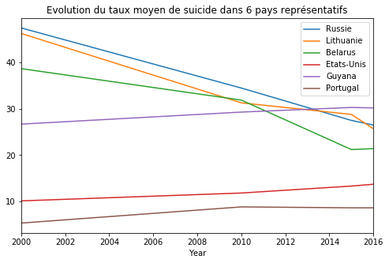

```python
fig, ax = plt.subplots(1, figsize=(8,5));
dfEvo.plot(x = 'Year', ax = ax);
ax.set_title("Evolution du taux moyen de suicide dans 6 pays représentatifs");

plt.savefig('NB4_3.png');
```